# A Final Test!

## Final Exercise

The points below outline in more detail what should be done:

- Import the data (example_human_genes.csv) using the `read.csv()` function
- Create a new column containing the absolute absolute fold change (Hint: use the `abs()` function)
- Filter the genes on the follow conditions:
  - Adjusted p-value less than or equal to 0.05
  - Absolute fold change greater than or equal to `log2(1.5)`

Next, use the provided mapping table (conversion_table.csv) to map between Ensembl ID and HGNC symbol.

Once the data has been filtered, create a plot with log2 fold change on the x-axis and adjusted p-value on the x-axis

Additionally, generate a histogram of the base mean for each genes. Set the number of bins to 50. For an extra challenge, change the theme to black and white. Change the bars to blue, with a black outline. Hint: The function you want is a variant of the `theme()` function from ggplot.

### Solution

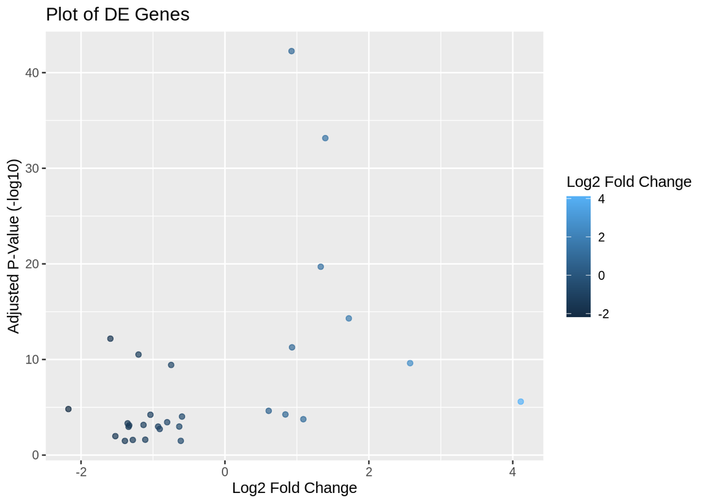

```r
suppressPackageStartupMessages(library(tidyverse))

DEGenes <- read.csv("../data/example_human_genes.csv")
conversion_table <- read.csv("../data/conversion_table.csv")


DEGenes_new <- DEGenes %>%
  mutate(abs_l2fc = abs(log2FoldChange)) %>%
  filter(padj <= 0.05, abs_l2fc >= log2(1.5))

DEGenes_joined <- DEGenes_new %>%
  left_join(., conversion_table, by = c("gene" = "ensembl_gene_id"))

ggplot(DEGenes_joined, aes(log2FoldChange, -log10(padj), colour = log2FoldChange)) +
  geom_point(alpha = 0.7) +
  labs(title = "Plot of DE Genes",
       x = "Log2 Fold Change",
       y ="Adjusted P-Value (-log10)",
       colour = "Log2 Fold Change")
```

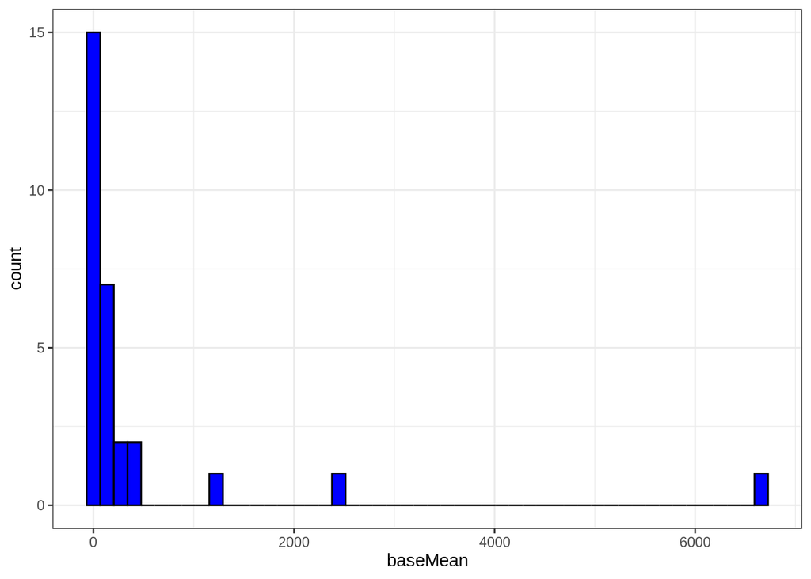

```r
ggplot(DEGenes_joined, aes(baseMean)) +
  geom_histogram(bins = 50, fill = "blue", colour = "black") +
  theme_bw()
```